# Exploratory Plots

### By ephemeris error

Could this be a response to ephemeris error? Perhaps they are trying to update their ephemeris with uncertainty?

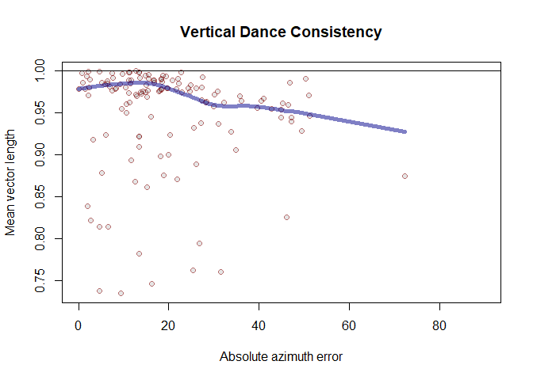

```r
plot(
  mean_vector ~  abs(Mod360.180(
          mu
        )
      ),
  data = subset(
    mean_vectors,
    condition %in% "vertical"
  ),
  xlim = c(0,1)*90,#possible range
  xlab = "Absolute azimuth error",
  ylab = "Mean vector length",
  main = "Vertical Dance Consistency",
  col = adjustcolor(
    cond_cols$vertical,
    alpha.f = 0.5
  ),
  bg = gray(level = 0, alpha = 0.1),
  pch = 21
)
abline(h = c(0, 1))
#add smooth curve
with(
  subset(
    mean_vectors,
    condition %in% c("vertical")
  ),
  {
    lines(
      LogitLoess(
        x = abs(Mod360.180(
          mu
        ) ),
        y = mean_vector
      ),

      col = adjustcolor(col = 'darkblue', alpha.f = 0.5),
      lwd = 5
    )
  }
)
```

### By sun elevation

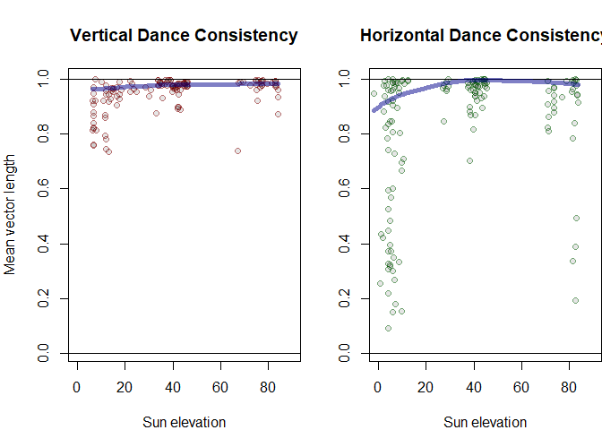

```r
par(mfrow = c(1,2),
    mar = c(4,4,4,0))
plot(
  mean_vector ~ sun_el,
  data = subset(
    mean_vectors,
    condition %in% "vertical"
  ),
  xlim = 90*c(0,1),#possible range
  ylim = c(0, 1)+ c(1,0)*0.01,
  xlab = "Sun elevation",
  ylab = "Mean vector length",
  main = "Vertical Dance Consistency",
  col = adjustcolor(
    cond_cols$vertical,
    alpha.f = 0.5
  ),
  bg = gray(level = 0, alpha = 0.1),
  pch = 21
)
abline(h = c(0, 1))
#add smooth curve
with(
  subset(
    mean_vectors,
    condition %in% c("vertical")
  ),
  {
    lines(
      LogitLoess(
        x = sun_el,
        y = mean_vector
      ),

      col = adjustcolor(col = 'darkblue', alpha.f = 0.5),
      lwd = 5
    )
  }
)

#horizontal
plot(
  mean_vector ~ sun_el,
  data = subset(
    mean_vectors,
    condition %in% "horizontal"
  ),
  xlim = 90*c(0,1),#possible range
  ylim = c(0, 1)+ c(1,0)*0.01,
  xlab = "Sun elevation",
  ylab = "",#"Mean vector length",
  main = "Horizontal Dance Consistency",
  col = adjustcolor(
    cond_cols$horizontal,
    alpha.f = 0.5
  ),
  bg = gray(level = 0, alpha = 0.1),
  pch = 21
)
abline(h = c(0, 1))
#add smooth curve
with(
  subset(
    mean_vectors,
    condition %in% c("horizontal")
  ),
  {
    lines(
      LogitLoess(
        x = sun_el,
        y = mean_vector
      ),

      col = adjustcolor(col = 'darkblue', alpha.f = 0.5),
      lwd = 5
    )
  }
)
```

## Direction

### By condition

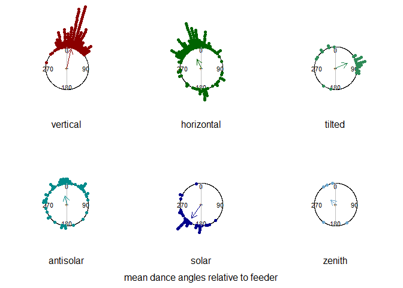

```r
par(mfrow = c(2,3),
    mar = c(0,0,0,0),
    oma = c(2,0,0,0))
for(cond in levels(hd$condition))
{
PCfun(angles = subset(mean_vectors,
                      subset = condition %in% cond)$mu,
      col = cond_cols[[cond]],
      shrink = 2.8,
      title = cond)
}
mtext(text = "mean dance angles relative to feeder",
      side = 1,
      line = 0.2,
      outer = TRUE)
```

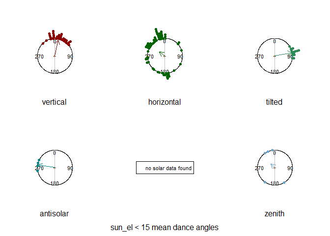

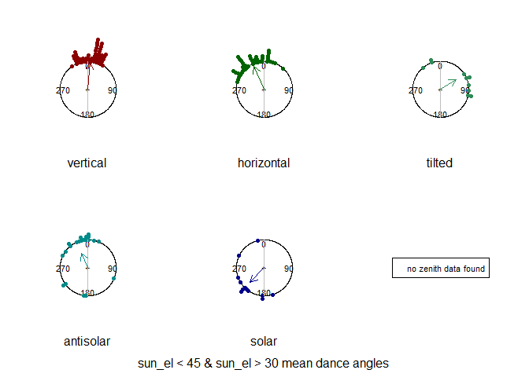

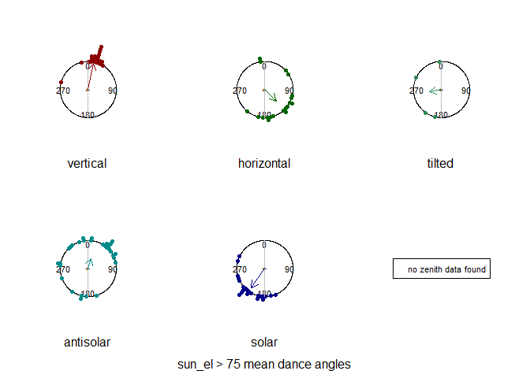

```r
for(tod in c('sun_el < 15',
             'sun_el < 45 & sun_el > 30',
             'sun_el > 75'
             )
    )
{

  # tod_filter = eval(str2lang(tod), envir = mean_vectors)
  for(cond in levels(hd$condition))
{
    cond_tod_mu = subset(mean_vectors,
                      subset = condition %in% cond &
                        eval(str2lang(tod))
                      )$mu
    if(length(cond_tod_mu)>0)
    {
PCfun(angles = cond_tod_mu,
      col = cond_cols[[cond]],
      shrink = 2.8,
      title = cond)
    }else
    {
       plot(
        NULL,
        axes = FALSE,
        xlim = c(0, 0),
        ylim = c(0, 0),
        xlab = "",
        ylab = "",
        main = ""
      )
      legend(x = "center",
             legend = paste("no", cond, "data found"))
    }
}
mtext(text = paste(tod, "mean dance angles"),
      side = 1,
      line = 0.2,
      outer = TRUE)

}
```

### By time of day

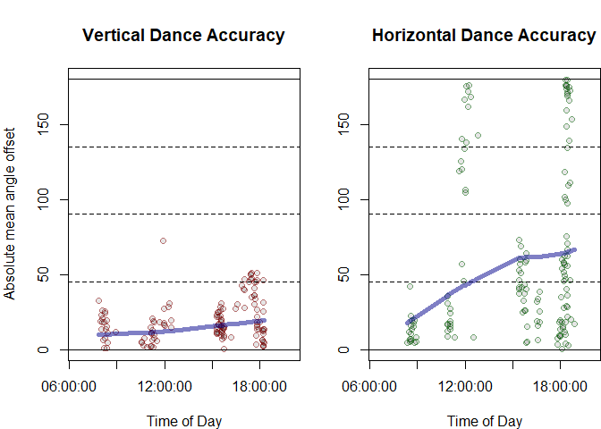

```r
par(
  mfrow = c(1, 2),
  mar = c(4, 4, 4, 0)
)
plot(
  abs(Mod360.180(mu)) ~ GetToD(time),
  data = subset(
    mean_vectors,
    condition %in% "vertical"
  ),
  xlim = range(exper_times) +
    60 * 60 * c(-1, 1), #experiment range +-1h
  ylim = c(0, 1) * 180,
  xlab = "Time of Day",
  ylab = "Absolute mean angle offset",
  main = "Vertical Dance Accuracy",
  col = adjustcolor(
    cond_cols$vertical,
    alpha.f = 0.5
  ),
  bg = gray(level = 0, alpha = 0.1),
  pch = 21
)
abline(h = 0:1 * c(180), lty = 1) #limits
abline(h = 1:3 * c(45), lty = 2) #gridlines
#add smooth curve
with(
  subset(
    mean_vectors,
    condition %in% c("vertical")
  ),
  {
    lines(
      LogitLoess(
        x = GetToD(time),
        y = abs(Mod360.180(mu)),
        absangle = TRUE,
        span = 1.0
      ),

      col = adjustcolor(
        col = 'darkblue',
        alpha.f = 0.5
      ),
      lwd = 5
    )
  }
)

#horizontal
plot(
  abs(Mod360.180(mu)) ~ GetToD(time),
  data = subset(
    mean_vectors,
    condition %in% "horizontal"
  ),
  xlim = range(exper_times) +
    60 * 60 * c(-1, 1), #experiment range +-1h
  ylim = c(0, 1) * 180,
  xlab = "Time of Day",
  ylab = "", #"Mean vector length",
  main = "Horizontal Dance Accuracy",
  col = adjustcolor(
    cond_cols$horizontal,
    alpha.f = 0.5
  ),
  bg = gray(level = 0, alpha = 0.1),
  pch = 21
)
abline(h = 0:1 * c(180), lty = 1) #limits
abline(h = 1:3 * c(45), lty = 2) #gridlines
#add smooth curve
with(
  subset(
    mean_vectors,
    condition %in% c("horizontal")
  ),
  {
    lines(
      LogitLoess(
        x = GetToD(time),
        y = abs(Mod360.180(mu)),
        absangle = TRUE,
        span = 1.0
      ),

      col = adjustcolor(
        col = 'darkblue',
        alpha.f = 0.5
      ),
      lwd = 5
    )
  }
)
```

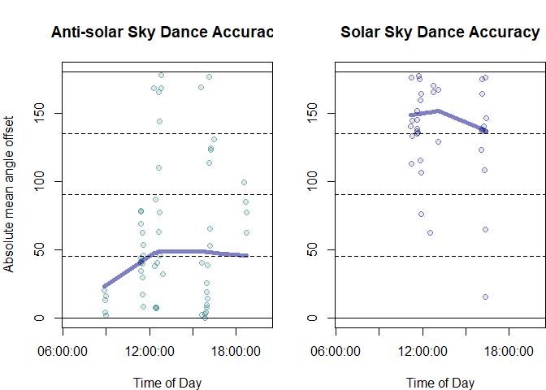

```r
#antisolar
plot(
  abs(Mod360.180(mu)) ~ GetToD(time),
  data = subset(
    mean_vectors,
    condition %in% "antisolar"
  ),
  xlim = range(exper_times) +
    60 * 60 * c(-1, 1), #experiment range +-1h
  ylim = c(0, 1) * 180,
  xlab = "Time of Day",
  ylab = "Absolute mean angle offset",
  main = "Anti-solar Sky Dance Accuracy",
  col = adjustcolor(
    cond_cols$antisolar,
    alpha.f = 0.5
  ),
  bg = gray(level = 0, alpha = 0.1),
  pch = 21
)
abline(h = 0:1 * c(180), lty = 1) #limits
abline(h = 1:3 * c(45), lty = 2) #gridlines
#add smooth curve
with(
  subset(
    mean_vectors,
    condition %in% c("antisolar")
  ),
  {
    lines(
      LogitLoess(
        x = GetToD(time),
        y = abs(Mod360.180(mu)),
        absangle = TRUE,
        span = 1.0
      ),

      col = adjustcolor(
        col = 'darkblue',
        alpha.f = 0.5
      ),
      lwd = 5
    )
  }
)

#solar
plot(
  abs(Mod360.180(mu)) ~ GetToD(time),
  data = subset(
    mean_vectors,
    condition %in% "solar"
  ),
  xlim = range(exper_times) +
    60 * 60 * c(-1, 1), #experiment range +-1h
  ylim = c(0, 1) * 180,
  xlab = "Time of Day",
  ylab = "", #"Mean vector length",
  main = "Solar Sky Dance Accuracy",
  col = adjustcolor(
        cond_cols$solar,
    alpha.f = 0.5
  ),
  bg = gray(level = 0, alpha = 0.1),
  pch = 21
)
abline(h = 0:1 * c(180), lty = 1) #limits
abline(h = 1:3 * c(45), lty = 2) #gridlines
#add smooth curve
with(
  subset(
    mean_vectors,
    condition %in% c("solar")
  ),
  {
    lines(
      LogitLoess(
        x = GetToD(time),
        y = abs(Mod360.180(mu)),
        absangle = TRUE,
        span = 1.0
      ),

      col = adjustcolor(
        col = 'darkblue',
        alpha.f = 0.5
      ),
      lwd = 5
    )
  }
)
```

### By sun elevation

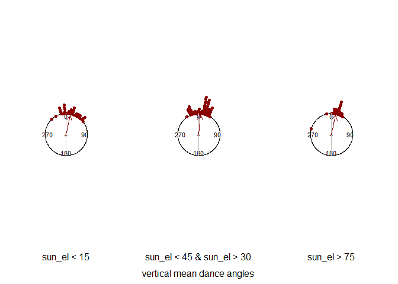

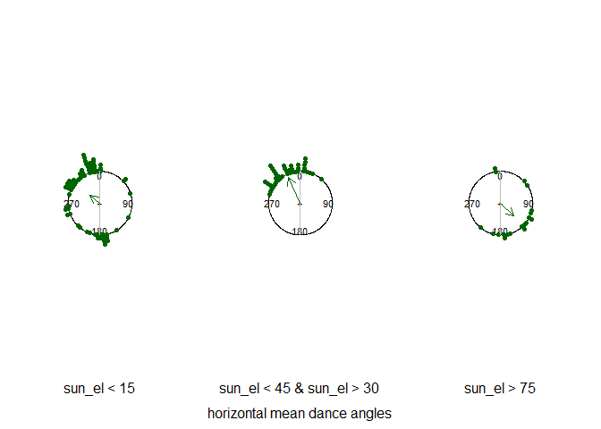

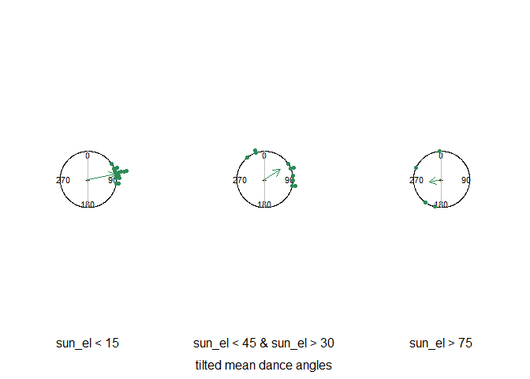

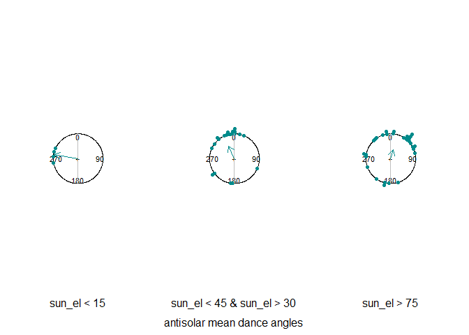

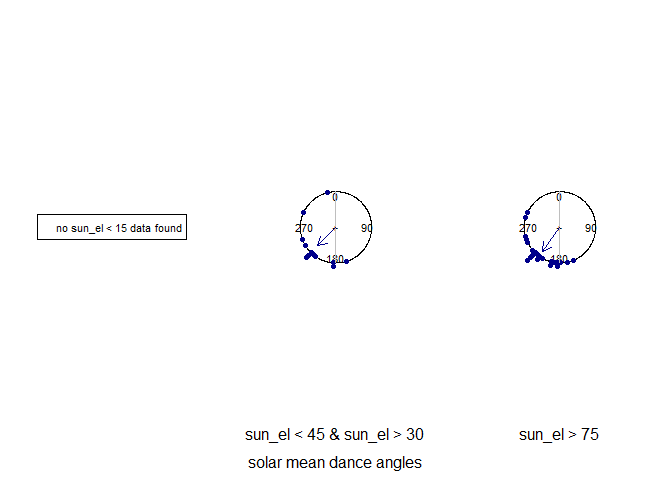

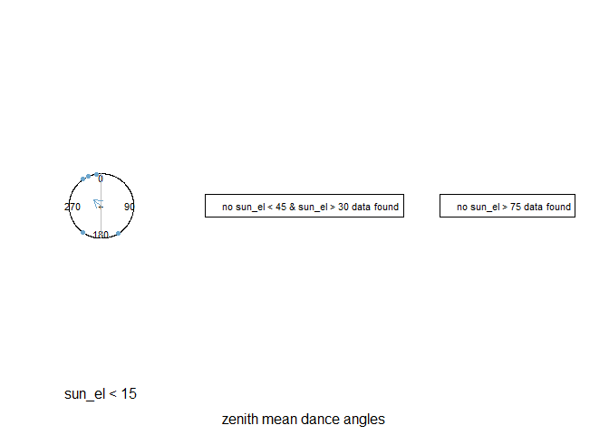

```r
par(
  mfrow = c(1, 3),
  mar = c(0, 0, 0, 0),
  oma = c(2, 0, 0, 0)
)

for (cond in levels(hd$condition)) {
  for (tod in c(
    'sun_el < 15',
    'sun_el < 45 & sun_el > 30',
    'sun_el > 75'
  )) {
    # tod_filter = eval(str2lang(tod), envir = mean_vectors)
    cond_tod_mu = subset(
      mean_vectors,
      subset = condition %in%
        cond &
        eval(str2lang(tod))
    )$mu
    if (length(cond_tod_mu) > 0) {
      PCfun(
        angles = cond_tod_mu,
        col = cond_cols[[cond]],
        shrink = 2.8,
        title = tod
      )
    } else {
      plot(
        NULL,
        axes = FALSE,
        xlim = c(0, 0),
        ylim = c(0, 0),
        xlab = "",
        ylab = "",
        main = ""
      )
      legend(
        x = "center",
        legend = paste(
          "no",
          tod,
          "data found"
        )
      )
    }
  }
    mtext(
      text = paste(
        cond,
        "mean dance angles"
      ),
      side = 1,
      line = 0.2,
      outer = TRUE
    )
}
```

Absolute offset by sun elevation.

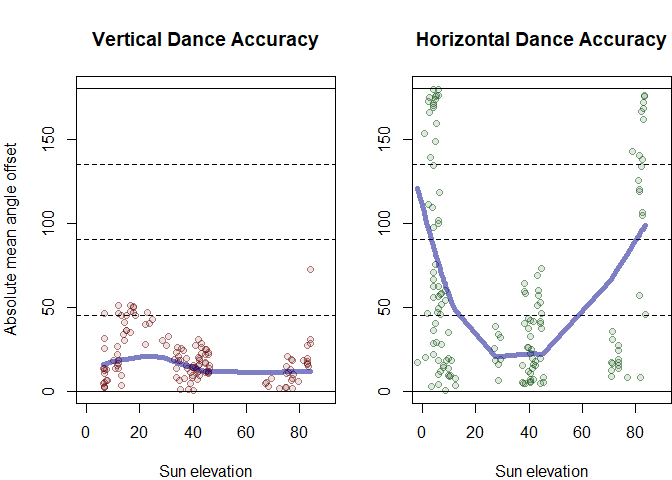

```r
par(mfrow = c(1,2),
    mar = c(4,4,4,0))
plot(
  abs(Mod360.180(mu)) ~ sun_el,
  data = subset(
    mean_vectors,
    condition %in% "vertical"
  ),
  xlim = 90*c(0,1),#possible range
  ylim = c(0, 1)*180,
  xlab = "Sun elevation",
  ylab = "Absolute mean angle offset",
  main = "Vertical Dance Accuracy",
  col = adjustcolor(
    cond_cols$vertical,
    alpha.f = 0.5
  ),
  bg = gray(level = 0, alpha = 0.1),
  pch = 21
)
abline(h = 0:1 * c(180), lty = 1) #limits
abline(h = 1:3 * c(45), lty = 2) #gridlines
#add smooth curve
with(
  subset(
    mean_vectors,
    condition %in% c("vertical")
  ),
  {
    lines(
      LogitLoess(
        x = sun_el,
        y = abs(Mod360.180(mu)),absangle = TRUE
      ),

      col = adjustcolor(col = 'darkblue', alpha.f = 0.5),
      lwd = 5
    )
  }
)

#horizontal
plot(
  abs(Mod360.180(mu)) ~ sun_el,
  data = subset(
    mean_vectors,
    condition %in% "horizontal"
  ),
  xlim = 90*c(0,1),#possible range
  ylim = c(0, 1)*180,
  xlab = "Sun elevation",
  ylab = "",#"Mean vector length",
  main = "Horizontal Dance Accuracy",
  col = adjustcolor(
    cond_cols$horizontal,
    alpha.f = 0.5
  ),
  bg = gray(level = 0, alpha = 0.1),
  pch = 21
)
abline(h = 0:1 * c(180), lty = 1) #limits
abline(h = 1:3 * c(45), lty = 2) #gridlines
#add smooth curve
with(
  subset(
    mean_vectors,
    condition %in% c("horizontal")
  ),
  {
    lines(
      LogitLoess(
        x = sun_el,
        y = abs(Mod360.180(mu)),absangle = TRUE
      ),

      col = adjustcolor(col = 'darkblue', alpha.f = 0.5),
      lwd = 5
    )
  }
)
```

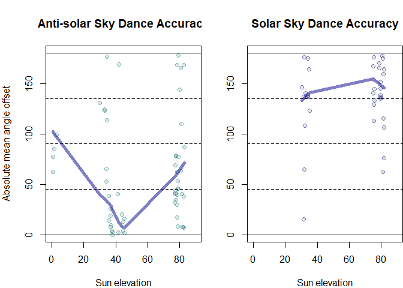

```r
#antisolar
plot(
  abs(Mod360.180(mu)) ~ sun_el,
  data = subset(
    mean_vectors,
    condition %in% "antisolar"
  ),
  xlim = 90*c(0,1),#possible range
  ylim = c(0, 1)*180,
  xlab = "Sun elevation",
  ylab = "Absolute mean angle offset",
  main = "Anti-solar Sky Dance Accuracy",
  col = adjustcolor(
    cond_cols$antisolar,
    alpha.f = 0.5
  ),
  bg = gray(level = 0, alpha = 0.1),
  pch = 21
)
abline(h = 0:1 * c(180), lty = 1) #limits
abline(h = 1:3 * c(45), lty = 2) #gridlines
#add smooth curve
with(
  subset(
    mean_vectors,
    condition %in% c("antisolar")
  ),
  {
    lines(
      LogitLoess(
        x = sun_el,
        y = abs(Mod360.180(mu)),absangle = TRUE
      ),

      col = adjustcolor(col = 'darkblue', alpha.f = 0.5),
      lwd = 5
    )
  }
)

#solar
plot(
  abs(Mod360.180(mu)) ~ sun_el,
  data = subset(
    mean_vectors,
    condition %in% "solar"
  ),
  xlim = 90*c(0,1),#possible range
  ylim = c(0, 1)*180,
  xlab = "Sun elevation",
  ylab = "",#"Mean vector length",
  main = "Solar Sky Dance Accuracy",
  col = adjustcolor(
    cond_cols$solar,
    alpha.f = 0.5
  ),
  bg = gray(level = 0, alpha = 0.1),
  pch = 21
)
abline(h = 0:1 * c(180), lty = 1) #limits
abline(h = 1:3 * c(45), lty = 2) #gridlines
#add smooth curve
with(
  subset(
    mean_vectors,
    condition %in% c("solar")
  ),
  {
    lines(
      LogitLoess(
        x = sun_el,
        y = abs(Mod360.180(mu)),absangle = TRUE
      ),

      col = adjustcolor(col = 'darkblue', alpha.f = 0.5),
      lwd = 5
    )
  }
)
```

# Condition contrasts

## Find pairs of dances

Find dances by the same individual within the same experiment for different conditions. Ideally these should be close together in time.

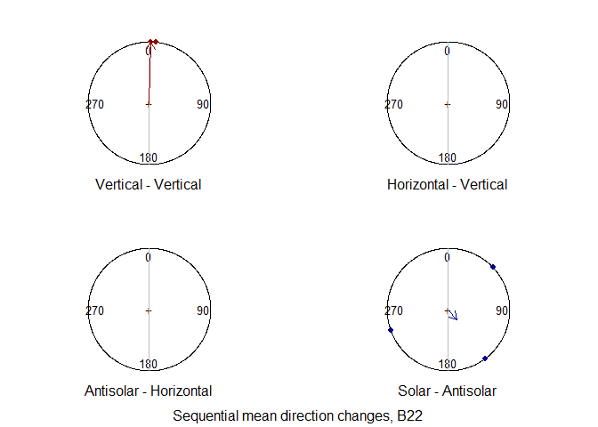

```r
#Test on one individual
id_test = "22b"

mv_subs_test = subset(mean_vectors,
                      ID %in% id_test)

mv_subs_test = within(mv_subs_test,
                      {
                      #find pairs of sequential dances
                      ID_d_pair = c(NA,
                                    sapply(X = unique(ID_d)[-1],
                                         FUN = function(i)
                                           {
                                         paste(ID_d[
                                           which(ID_d %in% i) + c(-1,0)
                                           ],
                                           collapse = " - "
                                           )
                                         }
                                         )
                                  )
                      #find pairs of sequential conditions
                      cond_pair = c(NA,
                                    sapply(X = unique(ID_d)[-1],
                                         FUN = function(i)
                                           {
                                         paste(condition[
                                           which(ID_d %in% i) + c(-1,0)
                                           ],
                                           collapse = " - "
                                           )
                                         }
                                         )
                                  )
                      el_diff = c(NA, #1st dance paired with nothing
                                  diff(sun_el)) # sequential differences in sun-elevation
                      day_diff = c(NA,
                                   diff(as.numeric(day)) )
                      is_paired = (abs(el_diff) < 15) & #elevation differs by less than 15°
                                  (day_diff == 0) #on (exactly) the same day
                      }
                      )

pairs_test = data.frame(
  do.call(what = rbind,
                     args = with(subset(x = mv_subs_test,
                    subset = is_paired),
                  strsplit(x = unique(ID_d_pair), split = " - ")
                  )
)
)
names(pairs_test) = c("dance1", "dance2")

#find dance conditions
pairs_test = within(pairs_test,
                    {
                      cond1 = sapply(X = dance1,
                                     FUN = function(i)
                                       {
                                       subset(mv_subs_test, ID_d %in% i)$condition
                                     }
                                    )
                      cond2 = sapply(X = dance2,
                                     FUN = function(i)
                                       {
                                       subset(mv_subs_test, ID_d %in% i)$condition
                                     }
                                    )
                    }
                    )
MuPairDiff = function(d1, d2, dta) {
  # print(dta); stop()
        subset(dta, dta$ID_d %in% d2)$mu -
          subset(dta, dta$ID_d %in% d1)$mu
      }
#vertical -> horizontal
vh_test_mu = with(
  subset(
    x = pairs_test,
    cond1 %in%
      "vertical" &
      cond2 %in% "horizontal"
  ),
  {
    mapply(
      FUN = MuPairDiff,
      d1 = dance1,
      d2 = dance2,
      dta = list(mean_vectors)
    )
  }
)
#horizontal -> vertical
hv_test_mu = with(
  subset(
    x = pairs_test,
    cond1 %in%
      "horizontal" &
      cond2 %in% "vertical"
  ),
  {
    mapply(
      FUN = MuPairDiff,
      d1 = dance1,
      d2 = dance2,
      dta = list(mean_vectors)
    )
  }
)
#vertical -> vertical
vv_test_mu = with(
  subset(
    x = pairs_test,
    cond1 %in%
      "vertical" &
      cond2 %in% "vertical"
  ),
  {
    mapply(
      FUN = MuPairDiff,
      d1 = dance1,
      d2 = dance2,
      dta = list(mean_vectors)
    )
  }
)
#horizontal -> antisolar
ha_test_mu = with(
  subset(
    x = pairs_test,
    cond1 %in%
      "horizontal" &
      cond2 %in% "antisolar"
  ),
  {
    mapply(
      FUN = MuPairDiff,
      d1 = dance1,
      d2 = dance2,
      dta = list(mean_vectors)
    )
  }
)
#antisolar -> horizontal
ah_test_mu = with(
  subset(
    x = pairs_test,
    cond1 %in%
      "antisolar" &
      cond2 %in% "horizontal"
  ),
  {
    mapply(
      FUN = MuPairDiff,
      d1 = dance1,
      d2 = dance2,
      dta = list(mean_vectors)
    )
  }
)
#antisolar -> solar
as_test_mu = with(
  subset(
    x = pairs_test,
    cond1 %in%
      "antisolar" &
      cond2 %in% "solar"
  ),
  {
    mapply(
      FUN = MuPairDiff,
      d1 = dance1,
      d2 = dance2,
      dta = list(mean_vectors)
    )
  }
)
#solar -> antisolar
sa_test_mu = with(
  subset(
    x = pairs_test,
    cond1 %in%
      "solar" &
      cond2 %in% "antisolar"
  ),
  {
    mapply(
      FUN = MuPairDiff,
      d1 = dance1,
      d2 = dance2,
      dta = list(mean_vectors)
    )
  }
)

  par(
    mfrow = c(2, 2),
    mar = c(0, 0, 0, 0),
    oma = c(1, 0, 0, 0)
  )
PCfun(vv_test_mu,
      col = cond_cols$vertical,
      title = "Vertical - Vertical")
# PCfun(c(vh_test_mu, -hv_test_mu),
#       col = cond_cols$horizontal,
#       title = "Horizontal - Vertical")
PCfun(c(vh_test_mu),
      col = cond_cols$horizontal,
      title = "Horizontal - Vertical")
# PCfun(c(ha_test_mu,-ah_test_mu),
#       col = cond_cols$antisolar,
#       title = "Antisolar - Horizontal")
PCfun(c(ha_test_mu),
      col = cond_cols$antisolar,
      title = "Antisolar - Horizontal")
# PCfun(c(as_test_mu,-sa_test_mu),
#       col = cond_cols$solar,
#       title = "Solar - Antisolar")
PCfun(c(as_test_mu),
      col = cond_cols$solar,
      title = "Solar - Antisolar")
mtext(text = "Sequential mean direction changes, B22",
           side = 1,
      line = -0.25,
      outer = TRUE)
```

Since mean vectors should be organised by calendar time by default, sorting them by individual will allow us to determine the sequential differences.

These can then be subset according to individual, and reorganised into true sequential pairs.

```r
#Sort mean vectors by individual

#sort by individual, then by date and time
#(dance IDs follow several file naming conventions, so alphabetical order is not chronological)
mean_vectors = mean_vectors[order(mean_vectors$ID,
                                  as.POSIXct(
                                    x = paste(mean_vectors$day, mean_vectors$time),
                                    tz = "Africa/Johannesburg",
                                    format = "%Y%m%d %H:%M:%OS"
                                  )
                                  ), ]

#check the date ordering
#are calendar dates in increasing order
#check for an individual with lots of dances
with(
  subset(mean_vectors, ID %in% "22b"),
  {
    #calculate calendar dates and take sequential differences
    tdiff = diff(as.POSIXct(
      x = paste(day, time),
      tz = "Africa/Johannesburg",
      format = "%Y%m%d %H:%M:%OS"
    ))
    if (all(!(tdiff < 0))) { #N.B. some videos were close and are labelled with the same time
      print(
        "For B22, all dance times are in increasing order"
      )
    } else {
      print(paste(
        paste(
          ID_d[
            which(tdiff < 0) +
              c(0, 1)
          ],
          collapse = " & "
        ),
        "are not in order!"
      ))
    }
  }
)
```

```
## [1] "For B22, all dance times are in increasing order"
```

```r
#Set up data.frame with 1st and 2nd dance details
ID_d1 = with(mean_vectors, ID_d[1:(length(u_id_d)-1)])#1st dances
ID_d2 = with(mean_vectors, ID_d[2:length(u_id_d)])#2nd dances
#align information about the pairs
mv_pairs = data.frame( cbind(
                  subset(mean_vectors, ID_d %in% ID_d1),
                  subset(mean_vectors, ID_d %in% ID_d2)
                  )
                )
#names(mv_pairs) #the names for the 2nd dance columns now end in ".1"

#select only dance pairs by the same individual
mv_pairs = subset(mv_pairs, ID == ID.1)

#select only dance pairs on the same day
mv_pairs = subset(mv_pairs, day == day.1)

#add columns for differences
mv_pairs = within(mv_pairs,
                  {
                    time_diff = as.POSIXct(
                                  x = paste(day.1, time.1),
                                  tz = "Africa/Johannesburg",
                                  format = "%Y%m%d %H:%M:%OS"
                                ) - as.POSIXct(
                                  x = paste(day, time),
                                  tz = "Africa/Johannesburg",
                                  format = "%Y%m%d %H:%M:%OS"
                                )#difference in time in seconds
                    ele_diff = sun_el.1 - sun_el
                    az_diff = Mod360.180(sun_az.1 - sun_az)
                    mv_diff = mean_vector.1 - mean_vector
                    kp_diff = kappa.1 - kappa
                    mu_diff = Mod360.180(mu.1 - mu)

                  }
                  )
#test again the all dances are sequential
with(
  mv_pairs,
  {
    if (all(!(time_diff < 0))) {
      print(
        "All dance pair times are in increasing order."
      )
    } else {
      message(paste(
        paste(
          ID_d[
            which(time_diff < 0)
          ],
          ID_d.1[
            which(time_diff < 0)
          ],
          "\n"
        ),
        "are not in order!\n"
      ))
    }
  }
)
```

```
## [1] "All dance pair times are in increasing order."
```

```r
mv_subs = subset(mv_pairs,
                      (abs(ele_diff) < 15) & #elevation differs by less than 15°
                                  (time_diff < 30*60) #less than 30 minutes
                      )
```

## Direction

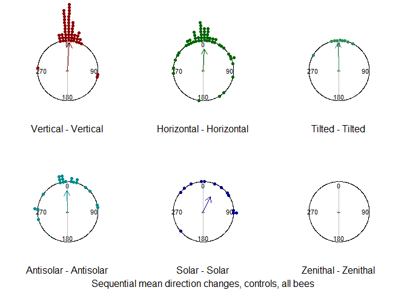

```r
par(
  mfrow = c(2, 3),
  mar = c(0, 0, 0, 0),
  oma = c(1, 0, 0, 0)
)
#all controls
PCfun(PairedDiff(dta = mv_subs,
  cond_1 = "vertical",
  cond_2 = "vertical"),
      shrink = 2.0,
      col = cond_cols$vertical,
      title = "Vertical - Vertical")

PCfun(PairedDiff(dta = mv_subs,
  cond_1 = "horizontal",
  cond_2 = "horizontal"),
      shrink = 2.0,
      col = cond_cols$horizontal,
      title = "Horizontal - Horizontal")
PCfun(PairedDiff(dta = mv_subs,
  cond_1 = "tilted",
  cond_2 = "tilted"),
      shrink = 2.0,
      col = cond_cols$tilted,
      title = "Tilted - Tilted")
PCfun(PairedDiff(dta = mv_subs,
  cond_1 = "antisolar",
  cond_2 = "antisolar"),
      shrink = 2.0,
      col = cond_cols$antisolar,
      title = "Antisolar - Antisolar")
PCfun(PairedDiff(dta = mv_subs,
  cond_1 = "solar",
  cond_2 = "solar"),
      shrink = 2.0,
      col = cond_cols$solar,
      title = "Solar - Solar")
PCfun(PairedDiff(dta = mv_subs,
  cond_1 = "zenith",
  cond_2 = "zenith"),
      shrink = 2.0,
      col = cond_cols$zenith,
      title = "Zenithal - Zenithal")
mtext(text = "Sequential mean direction changes, controls, all bees",
           side = 1,
      line = -0.25,
      outer = TRUE)
```

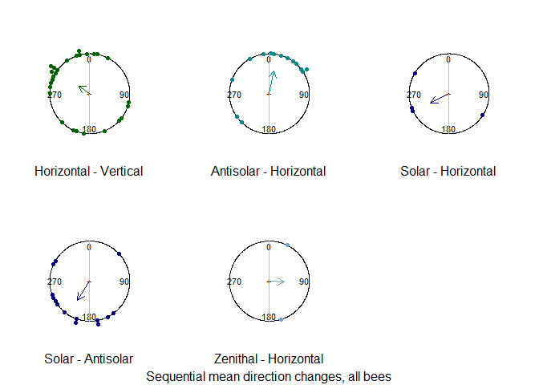

```r
par(
  mfrow = c(2, 3),
  mar = c(0, 0, 0, 0),
  oma = c(1, 0, 0, 0)
)

PCfun(angles = PairedDiff(dta =
  mv_subs,
  cond_1 = "vertical",
  cond_2 = "horizontal"
),
      shrink = 2.0,
      col = cond_cols$horizontal,
      title = "Horizontal - Vertical")

PCfun(angles =  PairedDiff(dta =
  mv_subs,
  cond_1 = "horizontal",
  cond_2 = "antisolar"
),
      shrink = 2.0,
      col = cond_cols$antisolar,
      title = "Antisolar - Horizontal")

PCfun(angles =  PairedDiff(dta =
  mv_subs,
  cond_1 = "horizontal",
  cond_2 = "solar"
),
      shrink = 2.0,
      col = cond_cols$solar,
      title = "Solar - Horizontal")

PCfun(angles = PairedDiff(dta =
  mv_subs,
  cond_1 = "antisolar",
  cond_2 = "solar"
),
      shrink = 2.0,
      col = cond_cols$solar,
      title = "Solar - Antisolar")

PCfun(PairedDiff(dta =
  mv_subs,
  cond_1 = "horizontal",
  cond_2 = "zenith"
),
      shrink = 2.0,
      col = cond_cols$zenith,
      title = "Zenithal - Horizontal")

mtext(text = "Sequential mean direction changes, all bees",
           side = 1,
      line = -0.25,
      outer = TRUE)
```

### Primary mean of bimodal dances

For dances where the best fitting model has two modes (`bim_mu2` is not `NA`), the unimodal mean (`mu`) can fall between the two modes. Instead, use the primary mean (`bim_mu1`) for these dances, and the unimodal mean for all others. The paired differences are saved as `bmu_diff` in `mv_pairs` and `mv_subs`, in the same format as `mu_diff`, so they can be used with `PairedDiff(..., diff_var = "bmu_diff")`. `BiMod_est` labels the modes so that the primary mean accounts for at least 50% of waggle runs (`bim_weight1` $\ge 0.5$).

```r
#add columns for differences, in the same format as mu_diff
#PrimaryMu (HS_functions.R) uses the primary mean for bimodal dances, otherwise the unimodal mean
mv_pairs = within(mv_pairs,
                  {
                    bimodal_pair = !is.na(bim_mu2) | !is.na(bim_mu2.1)#either dance is bimodal
                    bmu_diff = Mod360.180(
                                PrimaryMu(mu.1, bim_mu1.1, bim_mu2.1) -
                                PrimaryMu(mu, bim_mu1, bim_mu2)
                              )
                  }
                  )
#the subset keeps the row names of mv_pairs
mv_subs = within(mv_subs,
                 {
                   bimodal_pair = mv_pairs[rownames(mv_subs), 'bimodal_pair']
                   bmu_diff = mv_pairs[rownames(mv_subs), 'bmu_diff']
                 }
                 )
print(paste(sum(mv_subs$bimodal_pair), 'of', nrow(mv_subs),
            'dance pairs include a bimodal dance'))
```

```
## [1] "84 of 237 dance pairs include a bimodal dance"
```

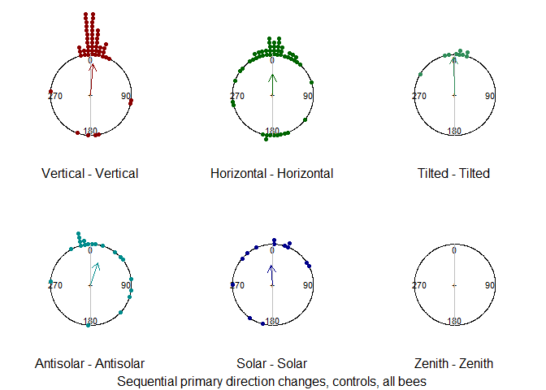

```r
#controls
par(
  mfrow = c(2, 3),
  mar = c(0, 0, 0, 0),
  oma = c(1, 0, 0, 0)
)
for (cond in names(cond_cols))
{
  PCfun(PairedDiff(dta = mv_subs,
                   cond_1 = cond,
                   cond_2 = cond,
                   diff_var = "bmu_diff"),
        shrink = 2.0,
        col = cond_cols[[cond]],
        title = tools::toTitleCase(paste(cond, '-', cond)))
}
mtext(text = "Sequential primary direction changes, controls, all bees",
           side = 1,
      line = -0.25,
      outer = TRUE)
```

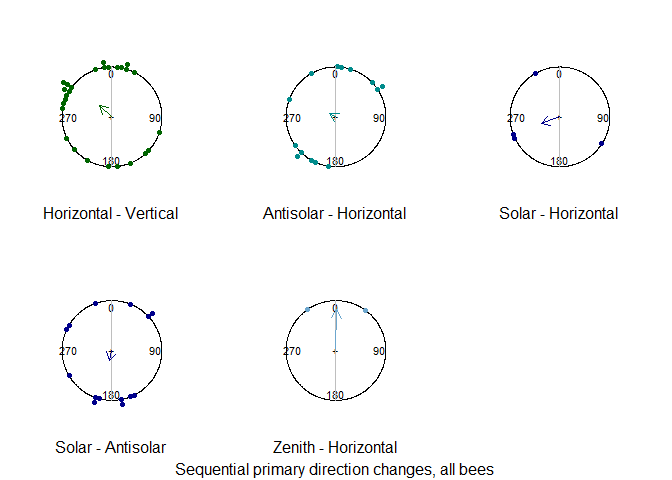

```r
#condition changes: 1st condition, 2nd condition
cond_pairs = list(c("vertical", "horizontal"),
                  c("horizontal", "antisolar"),
                  c("horizontal", "solar"),
                  c("antisolar", "solar"),
                  c("horizontal", "zenith")
                  )
par(
  mfrow = c(2, 3),
  mar = c(0, 0, 0, 0),
  oma = c(1, 0, 0, 0)
)
for (cp in cond_pairs)
{
  PCfun(PairedDiff(dta = mv_subs,
                   cond_1 = cp[1],
                   cond_2 = cp[2],
                   diff_var = "bmu_diff"),
        shrink = 2.0,
        col = cond_cols[[cp[2]]],
        title = tools::toTitleCase(paste(cp[2], '-', cp[1])))
}
mtext(text = "Sequential primary direction changes, all bees",
           side = 1,
      line = -0.25,
      outer = TRUE)
```

### By sun elevation

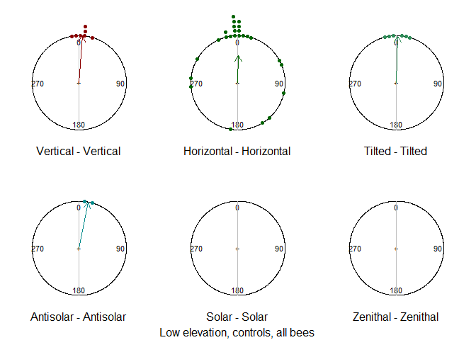

```r
mv_low = subset(mv_subs,
                sun_el <15)

par(
  mfrow = c(2, 3),
  mar = c(0, 0, 0, 0),
  oma = c(1, 0, 0, 0)
)
#all controls
PCfun(PairedDiff(dta = mv_low,
  cond_1 = "vertical",
  cond_2 = "vertical"),
      col = cond_cols$vertical,
      title = "Vertical - Vertical")

PCfun(PairedDiff(dta = mv_low,
  cond_1 = "horizontal",
  cond_2 = "horizontal"),
      col = cond_cols$horizontal,
      title = "Horizontal - Horizontal")
PCfun(PairedDiff(dta = mv_low,
  cond_1 = "tilted",
  cond_2 = "tilted"),
      col = cond_cols$tilted,
      title = "Tilted - Tilted")
PCfun(PairedDiff(dta = mv_low,
  cond_1 = "antisolar",
  cond_2 = "antisolar"),
      col = cond_cols$antisolar,
      title = "Antisolar - Antisolar")
PCfun(PairedDiff(dta = mv_low,
  cond_1 = "solar",
  cond_2 = "solar"),
      col = cond_cols$solar,
      title = "Solar - Solar")
PCfun(PairedDiff(dta = mv_low,
  cond_1 = "zenith",
  cond_2 = "zenith"),
      col = cond_cols$zenith,
      title = "Zenithal - Zenithal")
mtext(text = "Low elevation, controls, all bees",
           side = 1,
      line = -0.25,
      outer = TRUE)
```

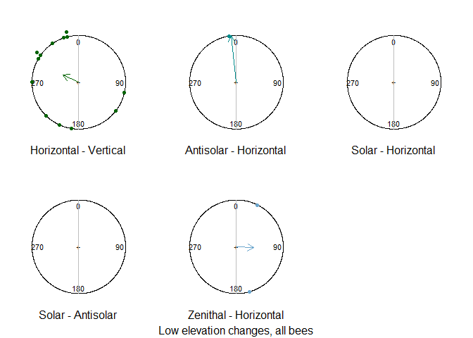

```r
PCfun(angles = PairedDiff(dta =
  mv_low,
  cond_1 = "vertical",
  cond_2 = "horizontal"
),
      col = cond_cols$horizontal,
      title = "Horizontal - Vertical")

PCfun(angles =  PairedDiff(dta =
  mv_low,
  cond_1 = "horizontal",
  cond_2 = "antisolar"
),
      col = cond_cols$antisolar,
      title = "Antisolar - Horizontal")

PCfun(angles =  PairedDiff(dta =
  mv_low,
  cond_1 = "horizontal",
  cond_2 = "solar"
),
      col = cond_cols$solar,
      title = "Solar - Horizontal")
PCfun(angles = PairedDiff(dta =
  mv_low,
  cond_1 = "antisolar",
  cond_2 = "solar"
),
      col = cond_cols$solar,
      title = "Solar - Antisolar")
PCfun(PairedDiff(dta =
  mv_low,
  cond_1 = "horizontal",
  cond_2 = "zenith"
),
      col = cond_cols$zenith,
      title = "Zenithal - Horizontal")

mtext(text = "Low elevation changes, all bees",
           side = 1,
      line = -0.25,
      outer = TRUE)
```

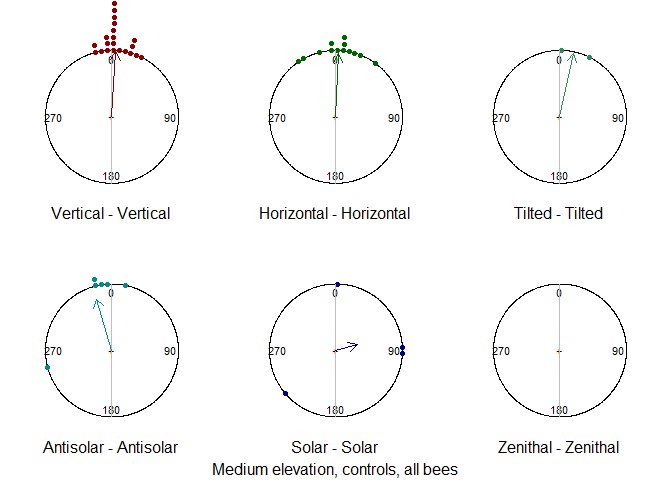

```r
mv_med = subset(mv_subs,
                sun_el >30 & sun_el <45)

par(
  mfrow = c(2, 3),
  mar = c(0, 0, 0, 0),
  oma = c(1, 0, 0, 0)
)
#all controls
PCfun(PairedDiff(dta = mv_med,
  cond_1 = "vertical",
  cond_2 = "vertical"),
      col = cond_cols$vertical,
      title = "Vertical - Vertical")

PCfun(PairedDiff(dta = mv_med,
  cond_1 = "horizontal",
  cond_2 = "horizontal"),
      col = cond_cols$horizontal,
      title = "Horizontal - Horizontal")
PCfun(PairedDiff(dta = mv_med,
  cond_1 = "tilted",
  cond_2 = "tilted"),
      col = cond_cols$tilted,
      title = "Tilted - Tilted")
PCfun(PairedDiff(dta = mv_med,
  cond_1 = "antisolar",
  cond_2 = "antisolar"),
      col = cond_cols$antisolar,
      title = "Antisolar - Antisolar")
PCfun(PairedDiff(dta = mv_med,
  cond_1 = "solar",
  cond_2 = "solar"),
      col = cond_cols$solar,
      title = "Solar - Solar")
PCfun(PairedDiff(dta = mv_med,
  cond_1 = "zenith",
  cond_2 = "zenith"),
      col = cond_cols$zenith,
      title = "Zenithal - Zenithal")
mtext(text = "Medium elevation, controls, all bees",
           side = 1,
      line = -0.25,
      outer = TRUE)
```

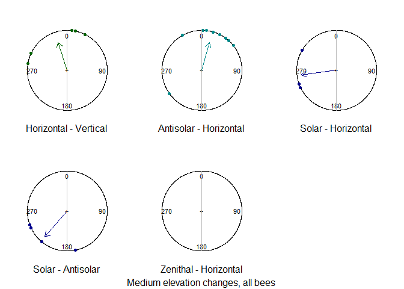

```r
PCfun(angles = PairedDiff(dta =
  mv_med,
  cond_1 = "vertical",
  cond_2 = "horizontal"
),
      col = cond_cols$horizontal,
      title = "Horizontal - Vertical")

PCfun(angles =  PairedDiff(dta =
  mv_med,
  cond_1 = "horizontal",
  cond_2 = "antisolar"
),
      col = cond_cols$antisolar,
      title = "Antisolar - Horizontal")

PCfun(angles =  PairedDiff(dta =
  mv_med,
  cond_1 = "horizontal",
  cond_2 = "solar"
),
      col = cond_cols$solar,
      title = "Solar - Horizontal")

PCfun(angles = PairedDiff(dta =
  mv_med,
  cond_1 = "antisolar",
  cond_2 = "solar"
),
      col = cond_cols$solar,
      title = "Solar - Antisolar")

PCfun(PairedDiff(dta =
  mv_med,
  cond_1 = "horizontal",
  cond_2 = "zenith"
),
      col = cond_cols$zenith,
      title = "Zenithal - Horizontal")
mtext(text = "Medium elevation changes, all bees",
           side = 1,
      line = -0.25,
      outer = TRUE)
```

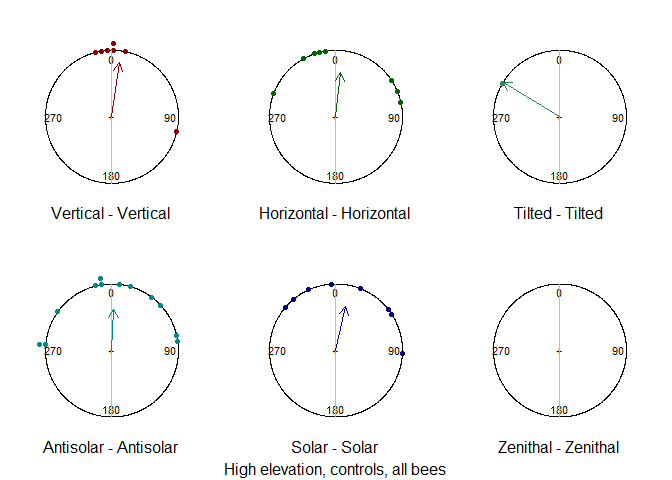

```r
mv_hig = subset(mv_subs,
                sun_el >75)

par(
  mfrow = c(2, 3),
  mar = c(0, 0, 0, 0),
  oma = c(1, 0, 0, 0)
)
#all controls
PCfun(PairedDiff(dta = mv_hig,
  cond_1 = "vertical",
  cond_2 = "vertical"),
      col = cond_cols$vertical,
      title = "Vertical - Vertical")

PCfun(PairedDiff(dta = mv_hig,
  cond_1 = "horizontal",
  cond_2 = "horizontal"),
      col = cond_cols$horizontal,
      title = "Horizontal - Horizontal")
PCfun(PairedDiff(dta = mv_hig,
  cond_1 = "tilted",
  cond_2 = "tilted"),
      col = cond_cols$tilted,
      title = "Tilted - Tilted")
PCfun(PairedDiff(dta = mv_hig,
  cond_1 = "antisolar",
  cond_2 = "antisolar"),
      col = cond_cols$antisolar,
      title = "Antisolar - Antisolar")
PCfun(PairedDiff(dta = mv_hig,
  cond_1 = "solar",
  cond_2 = "solar"),
      col = cond_cols$solar,
      title = "Solar - Solar")
PCfun(PairedDiff(dta = mv_hig,
  cond_1 = "zenith",
  cond_2 = "zenith"),
      col = cond_cols$zenith,
      title = "Zenithal - Zenithal")
mtext(text = "High elevation, controls, all bees",
           side = 1,
      line = -0.25,
      outer = TRUE)
```

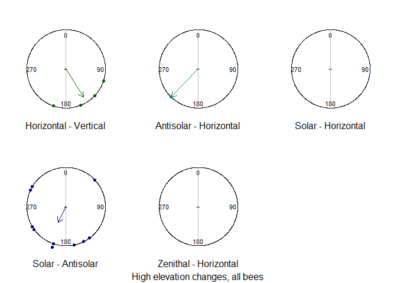

```r
PCfun(angles = PairedDiff(dta =
  mv_hig,
  cond_1 = "vertical",
  cond_2 = "horizontal"
),
      col = cond_cols$horizontal,
      title = "Horizontal - Vertical")

PCfun(angles =  PairedDiff(dta =
  mv_hig,
  cond_1 = "horizontal",
  cond_2 = "antisolar"
),
      col = cond_cols$antisolar,
      title = "Antisolar - Horizontal")

PCfun(angles =  PairedDiff(dta =
  mv_hig,
  cond_1 = "horizontal",
  cond_2 = "solar"
),
      col = cond_cols$solar,
      title = "Solar - Horizontal")
PCfun(angles = PairedDiff(dta =
  mv_hig,
  cond_1 = "antisolar",
  cond_2 = "solar"
),
      col = cond_cols$solar,
      title = "Solar - Antisolar")

PCfun(PairedDiff(dta =
  mv_hig,
  cond_1 = "horizontal",
  cond_2 = "zenith"
),
      col = cond_cols$zenith,
      title = "Zenithal - Horizontal")
mtext(text = "High elevation changes, all bees",
           side = 1,
      line = -0.25,
      outer = TRUE)
```